# Princípios básicos de modelagem

- Modelos em geral
- Modelos matemáticos
- Tipos de modelos
- Tipos de modelagem
- Ajuste de parâmetros
- Validação
- Escolha do modelo
- Quantificação de incertezas

## Modelos

- Um **modelo** é uma representação de algo:
  - Pessoa
  - Objeto
  - Conceito
  - Fenômeno
  - Etc.

### Exemplos de modelos

- Um **busto** é uma representação visual de um indivíduo;
- Um **perfil psicológico** é um modelo das características psicológicas de um indivíduo;
- Um **mapa** é um modelo geográfico, e.g. um mapa rodoviário, topográfico, geo-político, etc.

[figure not shown]

```julia
load(joinpath("img","modmat_model_examples.png"))
```

Créditos: [Imagem da rainha Nefertiti](https://commons.wikimedia.org/wiki/File:Nefertiti_30-01-2006.jpg?uselang=pt), [Star Wars pesonality test](https://www.geekinheels.com/2013/10/23/star-wars-mbti-chart.html) [Pesquisa CNT de rodovias](https://pesquisarodovias.cnt.org.br/)

### Modelo matemático

Um **modelo matemático** usa conceitos matemáticos nessas representações.

- Um **mapa rodoviário** pode ser um **grafo** conectando lugares. $$ \begin{align} & \qquad \qquad \qquad \fbox{Minas Gerais} \\ & \qquad \qquad \nearrow \qquad \quad \;\updownarrow \qquad \qquad \nwarrow \\ & \fbox{São Paulo} \longleftrightarrow \fbox{Rio de Janeiro} \longleftrightarrow \fbox{Espírito Santo} \end{align} $$
- A dependência da oferta $Q(P)$ de um produto em relação ao seu preço $P$ pode ser o de *elasticidade-constante* $\epsilon$, com uma **função** $$ Q(P) = C P^\epsilon. $$
- A dinâmica populacional de uma determinada espécie pode ser a **equação diferencial logística** $$ \frac{\text{d} x}{\text{d} t} = \alpha x - \beta x^2. $$

### Tipos de modelos

- estacionário x dinâmico
- determinístico x estocástico
- discreto x contínuo
- explícito x implícito
- macroscópico/microscópico x complexo
- diferencial x não-diferencial
- otimização x não-otimização

## Modelagem matemática

"Modelagem matemática é um processo que utiliza conceitos matemáticos para representar, analisar, fazer previsões e obter conhecimento de fenômenos do mundo real." - [GAIMME](https://m3challenge.siam.org/resources/teaching-modeling)

### Processo de modelagem

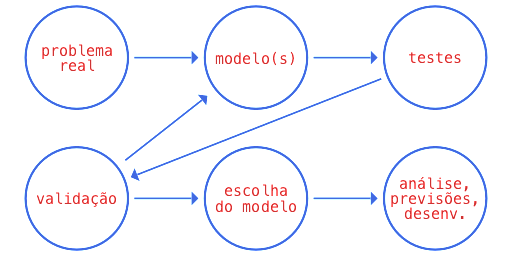

```julia
load(joinpath("img","mathmoddiag_512x256.png"))
```

### Tipos de modelagem

O processo de modelagem pode seguir vários caminhos:

- **empírico:** através da observação, seja de fenômenos reais, seja de experimentos controlados
- **análise dimensional:** baseado na análise das dimensões de quantidades envolvidas no fenômeno
- **ad-hoc:** introduzida sem muito fundamento e sem muita capacidade de generalização/extrapolação
- **mecanicista:** baseado em mecanismos envolvidos no fenômeno
  - **heurístico:** baseada em mecanismos qualitativos (e.g. os termos de interação entre duas espécies)
  - **fundamental:** baseado em relações/modelos bem estabelecidas e "precisos" (e.g. mecânica, termodinâmica, lei ação de massas)

Vale ressaltar que vários desses processos estão interligados.

## Ajuste de parâmetros

- Uma parte fundamental do processo de modelagem é o **ajuste de parâmetros**.
- Os modelos dependem, normalmente, de vários parâmetros.
- É fundamental termos dados reais para ajustar os parâmetros a esses dados, e assim modelar o fenômeno apropriadamente.
- Esse ajuste pode ser feito com várias técnicas, algumas das quais veremos ao longo do curso.
- E invariavelmente os dados reais contém **ruídos da medição** e/ou refletem **incertezas inerentes ao processo**. Nesse caso, conceitos estatísticos/probilísticos são necessários.

## Escolha do modelo

- Em muitos casos, vários modelos parecem ser apropriados.
- Não é tão imediato decidir qual deles será mais satisfatório para o problema em questão.
- Diversas técnicas podem ser utilizadas para verificar a robustez de um modelo a predições, evitando, em particular, um excesso de parâmetros que possam ajustar perfeitamente o modelo mas causar erros grosseiros de predição, algo conhecido como *over-fitting*.
- Há testes de validação cruzada e critérios de teoria de informação que iremos explorar com esse objetivo.

## Quantificação de incertezas

- Qualquer modelo contém **incertezas** em relação ao objeto da modelagem.
- Incertezas de **naturezas diversas:**
  - Aspectos não considerados no modelo;
  - Impossibilidade do fenômeno de ser completamente modelado;
  - Imprecisões nas medições;
  - Incertezas no ajuste de dados.
- Nesse sentido, é importante buscar quantificar essas incertezas e como elas afetam diversos aspectos oriundos da modelagem:
  - Predição
  - Representação
  - Análise
  - Robustez
- Há técnicas clássicas de análise de erro
  - Estatísticas/probilísticas (e.g. médias, desvio-padrão, cálculo de intervalos de confiança, análises de correlação)
  - Propagação local de erro, via análise de derivads
  - Propagação global de erro, via simulações de Monte-Carlo

## Conclusão

- Vimos acima diversos aspectos do processo de modelagem:
  - Observação
  - Elaboração do modelo
  - Ajuste de dados
  - Validação
  - Escolha do "melhor" modelo
  - Quantificação de incertezas
- Ao longo do curso, vamos analisar cada um desses aspectos
- Faremos isso buscando, também, trabalhar em cima de diversos casos concretos
- E através de projetos em que cada um de vocês terá a oportunidade de fazer na prática